# Recursos 12

9 actividades; factibilidad y duración en función de los operarios

# Enunciado

Considere el proyecto cuyo cuadro de prelaciones, duraciones (semanas) y operarios necesarios se adjunta. La empresa se plantea cuántos operarios contratar para el proyecto.

1. ¿Es posible ejecutar el proyecto con 4 operarios? Razónelo mirando sólo el cuadro de datos.

2. ¿Cuál es el número máximo de operarios que haría falta para ejecutar el proyecto en su duración mínima con las actividades en su inicio más temprano? ¿Y tras nivelar?

3. Construya la tabla «operarios disponibles → duración del proyecto» aplicando el algoritmo de asignación para cada número de operarios entre el mínimo factible y el máximo necesario.

4. Si cada operario cuesta 2 k€ por semana contratado durante todo el proyecto y cada semana de duración tiene un coste fijo de 5 k€, ¿cuántos operarios conviene contratar?

Tabla 1: Cuadro de datos del enunciado

| activity | predecessor | duration | resources |
| --- | --- | --- | --- |
| A | --- | 2 | 1 |
| B | --- | 8 | 2 |
| C | --- | 7 | 2 |
| D | A | 5 | 3 |
| E | B,C,D | 1 | 5 |
| F | E | 2 | 4 |
| G | E | 2 | 1 |
| H | D | 3 | 4 |
| I | G,H | 7 | 1 |

# Resolución

## Apartado 1

1. ¿Es posible ejecutar el proyecto con 4 operarios? Razónelo mirando sólo el cuadro de datos.

**Respuesta:** no. E necesita 5 operarios a la vez, más que los 4 disponibles, y una actividad no puede ejecutarse con menos operarios de los que requiere (no se admite alargarla). El mínimo factible es el mayor requerimiento de una actividad: 5 operarios.

## Apartado 2

2. ¿Cuál es el número máximo de operarios que haría falta para ejecutar el proyecto en su duración mínima con las actividades en su inicio más temprano? ¿Y tras nivelar?

Cálculo de los tiempos mínimos y máximos de los nodos del grafo Roy paso a paso. El primer paso muestra el grafo resuelto; a partir del siguiente se calcula desde el principio (avance con los botones):

[figure not shown]

paso 0 de 24

[figure not shown]

Figura 1: Grafo Roy con tiempos y camino crítico

Tabla 2: Calendario: fechas y holgura total de cada actividad

[figure not shown]

ninguna celda (0 de 72)

[figure not shown]

Haz clic en un número de la tabla para ver cómo se calcula.

👆 **Interactivo:** haz clic en cualquier celda de la tabla para ver cómo se calcula (otro clic la deselecciona), o usa los botones y las flechas del teclado.

| Actividad | Duración | Inicio más temprano | Fin más temprano | Inicio más tardío | Fin más tardío | H total | H libre | H independiente |
| --- | --- | --- | --- | --- | --- | --- | --- | --- |
| A | 2 | 0 | 2 | 1 | 3 | 1 | 0 | 0 |
| B | 8 | 0 | 8 | 0 | 8 | 0 | 0 | 0 |
| C | 7 | 0 | 7 | 1 | 8 | 1 | 1 | 1 |
| D | 5 | 2 | 7 | 3 | 8 | 1 | 0 | 0 |
| E | 1 | 8 | 9 | 8 | 9 | 0 | 0 | 0 |
| F | 2 | 9 | 11 | 16 | 18 | 7 | 7 | 7 |
| G | 2 | 9 | 11 | 9 | 11 | 0 | 0 | 0 |
| H | 3 | 7 | 10 | 8 | 11 | 1 | 1 | 0 |
| I | 7 | 11 | 18 | 11 | 18 | 0 | 0 | 0 |

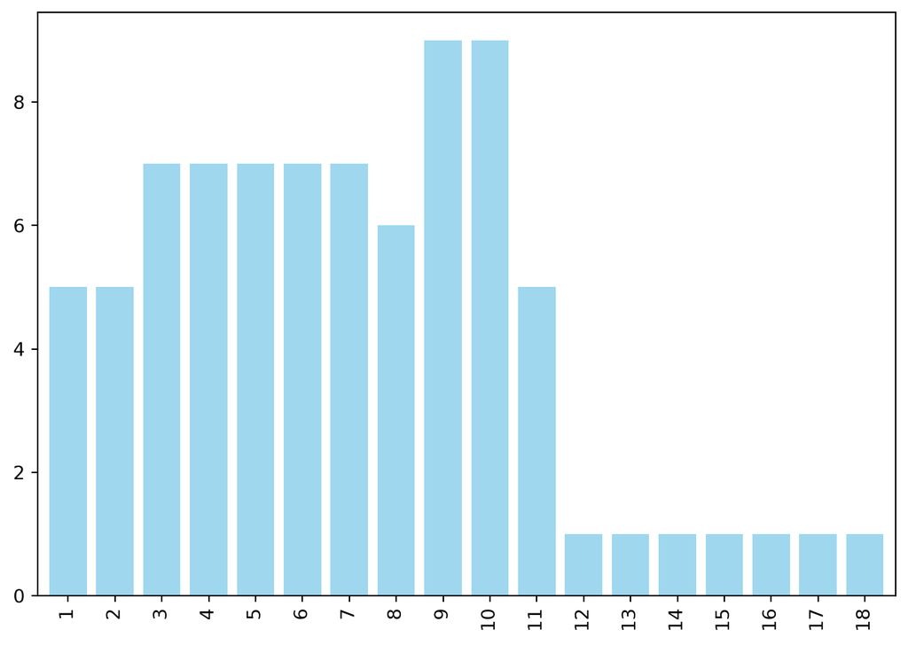

Figura 2: Cargas con las actividades en su inicio más temprano

La nivelación por mínimos cuadrados desplaza las actividades no críticas dentro de su holgura (sin cambiar la duración); la tabla da la suma de cuadrados de cada desplazamiento probado (resaltado el mínimo):

Tabla 3: Suma de cuadrados para cada desplazamiento posible

| activity | 0 | 1 | 2 | 3 | 4 | 5 | 6 | 7 |
| --- | --- | --- | --- | --- | --- | --- | --- | --- |
| A | 525 | 537 |  |  |  |  |  |  |
| C | 525 | 537 |  |  |  |  |  |  |
| D | 525 | 537 |  |  |  |  |  |  |
| H | 525 | 549 |  |  |  |  |  |  |
| F | 525 | 493 | 493 | 493 | 493 | 493 | 493 | 493 |

- A (holgura total 1): se prueban 0 a 1; suma mínima 525 con 0 → no se desplaza

- C (holgura total 1): se prueban 0 a 1; suma mínima 525 con 0 → no se desplaza

- D (holgura total 1): se prueban 0 a 1; suma mínima 525 con 0 → no se desplaza

- H (holgura total 1): se prueban 0 a 1; suma mínima 525 con 0 → no se desplaza

- F (holgura total 7): se prueban 0 a 7; suma mínima 493 con 1; empatan 1, 2, 3, 4, 5, 6 y 7 y se toma el menor → se desplaza **1 semana**

Cargas con inicios más tempranos: 5, 5, 7, 7, 7, 7, 7, 6, 9, 9, 5, 1, 1, 1, 1, 1, 1, 1 (máximo 9 en las semanas 9 y 10); tras nivelar: 5, 5, 7, 7, 7, 7, 7, 6, 9, 5, 5, 5, 1, 1, 1, 1, 1, 1 (máximo 9 en la semana 9). Sumas de cuadrados: 525 antes y 493 después.

**Respuesta:** con las actividades en su inicio más temprano hacen falta **9 operarios** y tras nivelar **9**, en ambos casos con la duración mínima de 18 semanas.

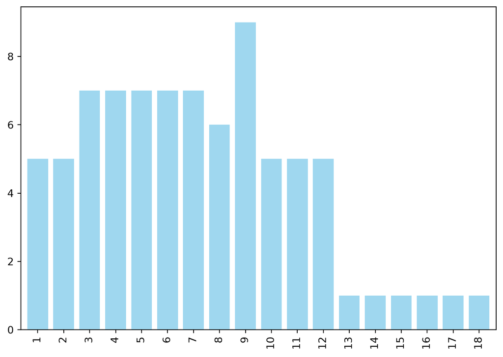

Figura 3: Cargas tras la nivelación

## Apartado 3

3. Construya la tabla «operarios disponibles → duración del proyecto» aplicando el algoritmo de asignación para cada número de operarios entre el mínimo factible y el máximo necesario.

Para cada número de operarios se aplica el algoritmo de asignación.

Regla del algoritmo: en cada semana se toman las actividades que el calendario vigente sitúa en ella y se ordenan así: primero las ya empezadas (no se interrumpen); después, menor holgura total (recalculada tras los aplazamientos anteriores) y, a igualdad, menor duración. Se admiten en ese orden mientras la suma de recursos no supere el límite; las que no caben se aplazan una semana (y con ellas sus sucesoras, si no tienen holgura). En la traza, *Total* es la demanda de esa semana antes de aplazar.

Con el mínimo factible se muestra la traza completa, el porqué de cada aplazamiento y el Gantt:

Periodo: 1.

Periodo: 1. Total: 5. Se programan: [‘A’, ‘B’, ‘C’]

Periodo: 2.

Periodo: 2. Total: 5. Se programan: [‘A’, ‘B’, ‘C’]

Periodo: 3.

Periodo: 3. Total: 7. Se programan: [‘B’, ‘C’]

Periodo: 3. Se desplazan: [‘D’]

Periodo: 4.

Periodo: 4. Total: 7. Se programan: [‘B’, ‘C’]

Periodo: 4. Se desplazan: [‘D’]

Periodo: 5.

Periodo: 5. Total: 7. Se programan: [‘B’, ‘C’]

Periodo: 5. Se desplazan: [‘D’]

Periodo: 6.

Periodo: 6. Total: 7. Se programan: [‘B’, ‘C’]

Periodo: 6. Se desplazan: [‘D’]

Periodo: 7.

Periodo: 7. Total: 7. Se programan: [‘B’, ‘C’]

Periodo: 7. Se desplazan: [‘D’]

Periodo: 8.

Periodo: 8. Total: 5. Se programan: [‘B’, ‘D’]

Periodo: 9.

Periodo: 9. Total: 3. Se programan: [‘D’]

Periodo: 10.

Periodo: 10. Total: 3. Se programan: [‘D’]

Periodo: 11.

Periodo: 11. Total: 3. Se programan: [‘D’]

Periodo: 12.

Periodo: 12. Total: 3. Se programan: [‘D’]

Periodo: 13.

Periodo: 13. Total: 9. Se programan: [‘E’]

Periodo: 13. Se desplazan: [‘H’]

Periodo: 14.

Periodo: 14. Total: 9. Se programan: [‘H’, ‘G’]

Periodo: 14. Se desplazan: [‘F’]

Periodo: 15.

Periodo: 15. Total: 9. Se programan: [‘H’, ‘G’]

Periodo: 15. Se desplazan: [‘F’]

Periodo: 16.

Periodo: 16. Total: 8. Se programan: [‘H’]

Periodo: 16. Se desplazan: [‘F’]

Periodo: 17.

Periodo: 17. Total: 5. Se programan: [‘I’, ‘F’]

Periodo: 18.

Periodo: 18. Total: 5. Se programan: [‘I’, ‘F’]

Periodo: 19.

Periodo: 19. Total: 1. Se programan: [‘I’]

Periodo: 20.

Periodo: 20. Total: 1. Se programan: [‘I’]

Periodo: 21.

Periodo: 21. Total: 1. Se programan: [‘I’]

Periodo: 22.

Periodo: 22. Total: 1. Se programan: [‘I’]

Periodo: 23.

Periodo: 23. Total: 1. Se programan: [‘I’]

Tabla 4: Semanas con conflicto con el mínimo de operarios

| semana | límite | demanda | orden de prioridad (holgura, duración, recurso) | entran | se aplazan una semana (no caben) |
| --- | --- | --- | --- | --- | --- |
| 3 | 5 | 7 | B (en curso, 2) › C (en curso, 2) › D (H=1, d=5, 3) | B y C | D: 4 + 3 = 7 > 5 |
| 4 | 5 | 7 | B (en curso, 2) › C (en curso, 2) › D (H=0, d=5, 3) | B y C | D: 4 + 3 = 7 > 5 |
| 5 | 5 | 7 | B (en curso, 2) › C (en curso, 2) › D (H=0, d=5, 3) | B y C | D: 4 + 3 = 7 > 5 |
| 6 | 5 | 7 | B (en curso, 2) › C (en curso, 2) › D (H=0, d=5, 3) | B y C | D: 4 + 3 = 7 > 5 |
| 7 | 5 | 7 | B (en curso, 2) › C (en curso, 2) › D (H=0, d=5, 3) | B y C | D: 4 + 3 = 7 > 5 |
| 13 | 5 | 9 | E (H=0, d=1, 5) › H (H=0, d=3, 4) | E | H: 5 + 4 = 9 > 5 |
| 14 | 5 | 9 | H (H=0, d=3, 4) › G (H=1, d=2, 1) › F (H=8, d=2, 4) | G y H | F: 5 + 4 = 9 > 5 |
| 15 | 5 | 9 | H (en curso, 4) › G (en curso, 1) › F (H=7, d=2, 4) | G y H | F: 5 + 4 = 9 > 5 |
| 16 | 5 | 8 | H (en curso, 4) › F (H=6, d=2, 4) | H | F: 4 + 4 = 8 > 5 |

[figure not shown]

Figura 4: Gantt con el mínimo de operarios factible

| operarios | duración (semanas) | esperas introducidas |
| --- | --- | --- |
| 5 | 23 | D (5 semanas), H (1 semana), F (3 semanas) |
| 6 | 23 | D (5 semanas), H (1 semana), F (3 semanas) |
| 7 | 20 | E (2 semanas) |
| 8 | 20 | E (2 semanas) |
| 9 | 18 | ninguna |

**Respuesta:** con 5 operarios, 23 semanas; con 6 operarios, 23 semanas; con 7 operarios, 20 semanas; con 8 operarios, 20 semanas; con 9 operarios, 18 semanas. Con 9 operarios (el máximo del calendario nivelado) se alcanza ya la duración mínima de 18 semanas.

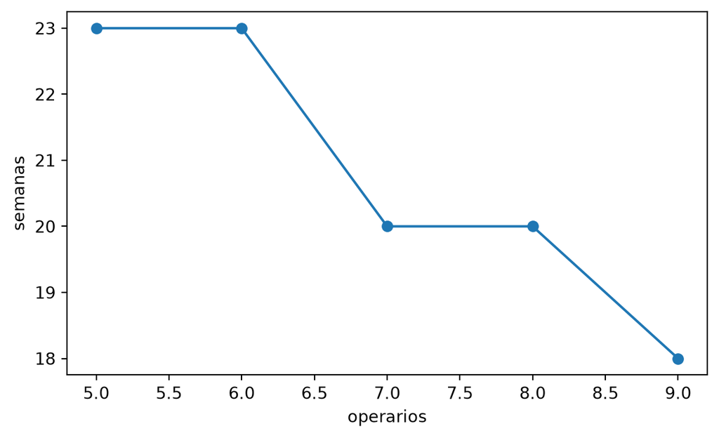

Figura 5: Duración del proyecto según los operarios disponibles

## Apartado 4

4. Si cada operario cuesta 2 k€ por semana contratado durante todo el proyecto y cada semana de duración tiene un coste fijo de 5 k€, ¿cuántos operarios conviene contratar?

Coste de cada opción: operarios × duración × 2 k€ (cada operario se paga todas las semanas del proyecto) más duración × 5 k€ de coste fijo.

| operarios | duración (semanas) | esperas introducidas | coste operarios | coste fijo | coste total |
| --- | --- | --- | --- | --- | --- |
| 5 | 23 | D (5 semanas), H (1 semana), F (3 semanas) | 230 | 115 | 345 |
| 6 | 23 | D (5 semanas), H (1 semana), F (3 semanas) | 276 | 115 | 391 |
| 7 | 20 | E (2 semanas) | 280 | 100 | 380 |
| 8 | 20 | E (2 semanas) | 320 | 100 | 420 |
| 9 | 18 | ninguna | 324 | 90 | 414 |

- 5 operarios: 2 · 5 · 23 + 5 · 23 = 230 + 115 = 345 k€

- 6 operarios: 2 · 6 · 23 + 5 · 23 = 276 + 115 = 391 k€

- 7 operarios: 2 · 7 · 20 + 5 · 20 = 280 + 100 = 380 k€

- 8 operarios: 2 · 8 · 20 + 5 · 20 = 320 + 100 = 420 k€

- 9 operarios: 2 · 9 · 18 + 5 · 18 = 324 + 90 = 414 k€

**Respuesta:** conviene contratar **5 operarios** (345 k€, 23 semanas). Más operarios acortan el proyecto pero cuestan cada semana; la tabla operarios-duración tiene escalones porque el plazo solo baja cuando el límite libera un cuello de botella, y añadir un operario que no acorta el proyecto solo encarece.